# 4 Consolidación de las bases de datos

Autor/a

Mario Camacho

Fecha de publicación

05 mayo 2026

## 4.1 Base de datos para los objetivos 1 y 3

Dimensiones de las bases de datos:

```
Pediatría:
  - Filas:  56706
  - Columnas:  25

 Pediatría + Hospitalización:
  - Filas:  56706
  - Columnas:  86

 Pediatría + Hospitalización + Protocolo salud:
  - Filas:  56706
  - Columnas:  94
```

El objetivo del estudio es evaluar las infecciones ocurridas durante el primer año de vida. Se ha detectado una limitación temporal en el seguimiento de eventos: aunque la cohorte de nacimientos incluye individuos nacidos hasta diciembre de 2022, la base de hospitalizaciones también finaliza en diciembre de 2022. Por lo que los individuos nacidos en 2022 no disponen de un periodo completo de seguimiento de doce meses para la detección del evento de interés (infecciones respiratorias y digestivas).

Esta situación genera una infraobservación sistemática de eventos en la cohorte de los nacidos en 2022, cuyo tiempo efectivo de observación es menor.  
- No sabemos si homogéneamente en la cohorte o especialmente en los nacidos en los últimos meses de 2022, es interesante estudiar el tiempo desde nacimiento hasta primera hospitalización.  
- Un análisis de supervivencia con el tiempo desde el nacimiento hasta la fecha del ingreso para medir la mediana del tiempo hasta el ingreso.

Como consecuencia, la incidencia de infecciones en dicha cohorte puede estar artificialmente infraestimada.

Se recomienda restringir la base de datos hasta los nacidos hasta el 31 de diciembre de 2021, últimos casos con periodo de seguimiento completo de un año.

```
Pediatría:
  - Filas:  56706
  - Columnas:  25

 Pediatría + Hospitalización + Protocolo salud:
  - Filas:  56706
  - Columnas:  94
```

Eliminamos las variables que no aportan información.

Columnas eliminadas y motivo

| Columna | Motivo |
| --- | --- |
| D14 | Todo los valores son NA |
| D15 | Todo los valores son NA |
| D16 | Todo los valores son NA |
| D17 | Todo los valores son NA |
| D18 | Todo los valores son NA |
| D19 | Todo los valores son NA |
| D20 | Todo los valores son NA |
| EDAD | Variable constante |
| D5_desc | Variable constante |
| D6_desc | Variable constante |
| D7_desc | Todo los valores son NA |
| D8_desc | Todo los valores son NA |
| D9_desc | Todo los valores son NA |
| D10_desc | Todo los valores son NA |
| D11_desc | Todo los valores son NA |
| D12_desc | Todo los valores son NA |
| Calendariovacunacion | Todo los valores son NA |

### 4.1.1 Nuevas variables

```
'data.frame':   56706 obs. of  3 variables:
 $ tiene_infecciones: Factor w/ 2 levels "0","1": 1 1 ...
 $ n_infecciones    : num  0 0 ...
 $ n_infecciones_fct: Factor w/ 5 levels "0","1","2","3",..: 1 1 ...
```

Distribución de niños según diagnóstico (hospitalización) y año de nacimiento

| year_nacimiento | 0 diagnósticos | > 0 diagnósticos |
| --- | --- | --- |
| 2018 | 11601 (94.63%) | 658 (5.37%) |
| 2019 | 11287 (95.58%) | 522 (4.42%) |
| 2020 | 10671 (98.30%) | 184 (1.70%) |
| 2021 | 10361 (95.33%) | 508 (4.67%) |
| 2022* | 10539 (96.56%) | 375 (3.44%) |

0 diagnósticos = sin infecciones (no hospitalizado) > 0 diagnósticos = con infecciones (hospitalizado)

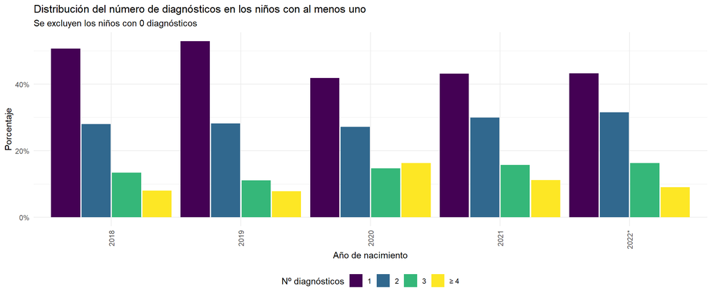

Distribución de niños según diagnóstico (hospitalización) y tipo de lactancia

| tipo_lactancia | 0 diagnósticos | > 0 diagnósticos |
| --- | --- | --- |
| Materna | 27864 (96.42%) | 1034 (3.58%) |
| Artificial | 8488 (94.44%) | 500 (5.56%) |
| Mixta | 8826 (96.27%) | 342 (3.73%) |
| NA | 9281 (96.16%) | 371 (3.84%) |

0 diagnósticos = sin infecciones (no hospitalizado) > 0 diagnósticos = con infecciones (hospitalizado)

## 4.2 Base de datos para el objetivo 2

**Nota**

Nótese la importancia semántica de usar `Pediatría + Hospitalización` o `Hospitalización + Pediatría`.

**Creación de la base de datos final para el análisis de datos y la inferencia sobre la sostenibilidad del sistema sanitario.**

- Base de datos de `Pediatría`: tiene CIP_ANON pero nada que lo relacione con ZBS -> los datos individuales de tipo de lactancia y duranción de la lactancia materna no podemos relacionarlos con los ZBS/GAI.
- Base de datos de `Hospitalización`: tiene CIP_ANON y CENTRO, podemos relacionarlo con ZBS -> se puede hacer un seguimiento de las hospitalizaciones y costes por ZBS, pero no se pueden relacionar con el número de nacimientos por año.
- Solo podemos geolocalizar las hospitalizaciones, no los nacimientos.

A `Hospitalización` le añado `Pediatría`.  
- Habrá datos de hospitalización sin datos de pediatría, no me importa si voy a mirar GRD por zonas.  
- Si voy a mirar datos basales por zona (como sí o sí tengo que pasar por hospitalización), tendré que usar únicamente datos de hospitalización con datos de pediatría.

```
##
##     0     1
## 64381  4449
##
##    1
## 4449
```

A la base de datos `Hospitalización + Pediatría` le añado el nombre de su ZBS usando la base de datos `Códigos de ZBS y provincia`. Los datos se filtran **solo** para la provincia de Toledo, es decir, se filtran **las hospitalizaciones de Toledo**, no los nacimientos. No contamos con la ZBS de los nacimientos.

Códigos ZBS de la base de datos de `Hospitalización + Pediatría` sin correspondencia en la base de datos `Códigos de ZBS y provincia` y valores sin informar:

```
     ZBS frecuencia
1   <NA>        453
2 110800         35
3 110817         13
4 110200          1
5 119902          1
```

Dimensiones de las bases de datos:

```
Hospitalización + Pediatría:
  - Filas:  4449
  - Columnas:  86

 Hospitalización + Pediatría + ZBS:
  - Filas:  4449
  - Columnas:  88

 Hospitalización + Pediatría + ZBS informado:
  - Filas:  3946
  - Columnas:  88

 Hospitalización + Pediatría + ZBS informado (solo hospitalizaciones Toledo):
  - Filas:  383
  - Columnas:  88

 Hospitalización + Pediatría informado + ZBS informado (solo hospitalizaciones Toledo):
  - Filas:  138
  - Columnas:  88
```

```
<list_of<
  tbl_df<
    GAI     : character
    ZBS_desc: character
    n       : integer
  >
>[14]>
[[1]]
# A tibble: 22 × 3
   GAI      ZBS_desc                n
   <chr>    <chr>               <int>
 1 ALBACETE ALCADOZO                4
 2 ALBACETE ALCARAZ                 5
 3 ALBACETE BALAZOTE                9
 4 ALBACETE CASAS DE JUAN NUÑEZ    10
 5 ALBACETE CASAS IBAÑEZ           14
 6 ALBACETE CASASIMARRO            16
 7 ALBACETE CHINCHILLA             17
 8 ALBACETE INIESTA                17
 9 ALBACETE LA RODA                60
10 ALBACETE MADRIGUERAS            12
# ℹ 12 more rows

[[2]]
# A tibble: 3 × 3
  GAI     ZBS_desc     n
  <chr>   <chr>    <int>
1 ALMANSA ALMANSA     60
2 ALMANSA BONETE      15
3 ALMANSA CAUDETE     39

[[3]]
# A tibble: 16 × 3
   GAI         ZBS_desc                    n
   <chr>       <chr>                   <int>
 1 CIUDAD REAL AGUDO                       1
 2 CIUDAD REAL ALCOBA DE LOS MONTES        2
 3 CIUDAD REAL ALMAGRO                    23
 4 CIUDAD REAL BOLAÑOS                    29
 5 CIUDAD REAL CALZADA DE CALATRAVA        9
```

[output cut: 148 more lines]

```
6 VALDEPEÑAS VALDEPEÑAS II           38
7 VALDEPEÑAS VILLAHERMOSA             5
8 VALDEPEÑAS VILLANUEVA INFANTES     16

[[14]]
# A tibble: 7 × 3
  GAI           ZBS_desc            n
  <chr>         <chr>           <int>
1 VILLARROBLEDO EL BONILLO          2
2 VILLARROBLEDO LAS PEDROÑERAS     20
3 VILLARROBLEDO MUNERA              4
4 VILLARROBLEDO OSSA DE MONTIEL     1
5 VILLARROBLEDO SAN CLEMENTE       25
6 VILLARROBLEDO SISANTE             5
7 VILLARROBLEDO VILLARROBLEDO      68
```

Nos quedamos únicamente con los registros donde `GAI='TOLEDO'`.

Los costes medios APR los hemos obtenidos del [Portal Estadístico](https://pestadistico.inteligenciadegestion.sanidad.gob.es/publicoSNS/C/rae-cmbd/rae-cmbd/grupos-relacionados-por-el-diagnostico-grd/grd-estadisticos-por-comunidad-autonoma-grupo-de-hospitales-servicios).

Ejemplo:

```
##   GRD year_ingreso    ZBS   CIP_ANON Fecha de nacimiento sexo Peso al nac
## 1 138         2018 110732 2447525061                <NA> <NA>          NA
##   e. madre Control e. maternal lugar_parto tipo_parto Apgar 1MIN Apgar 5MIN
## 1       NA    <NA>        <NA>        <NA>       <NA>         NA         NA
##   edad gestacional Fecha del alta tipo_lactancia d. lac materna
## 1               NA           <NA>           <NA>             NA
##   formulas especiales Test metabolopatías Fecha Test
## 1                <NA>                <NA>       <NA>
##   Resultado test metabolopatías mes_nacimiento year_nacimiento mes_alta
## 1                          <NA>           <NA>            <NA>     <NA>
##   year_alta mes_test year_test SEXO    D1     D2    D3    D4    D5   D6   D7
## 1      <NA>     <NA>      <NA>    1 J12.1 J98.01 K21.9 R06.9 R00.0 <NA> <NA>
##     D8   D9  D10  D11  D12  D13 D14 D15 D16 D17 D18 D19 D20 UCI DIAS_UCI
## 1 <NA> <NA> <NA> <NA> <NA> <NA>  NA  NA  NA  NA  NA  NA  NA   1      8.2
##               FEC_FIN TIPALT HOSPTRAS
## 1 2018-01-18 20:49:00      1     <NA>
##                                                 DESCRIPCION EDAD ENF_INF_INT
## 1 BRONQUIOLITIS Y NEUMONÍA POR VIRUS SINCITIAL RESPIRATORIO    0           0
##   OTRAS_BACT EXANT OTRAS_INF COVID INF_AGU_TRS GRIP_NEUMON BRONQ DIGEST
## 1          0     0         0     0           0           1     0      0
##   OIDO_MAST ENF_MENIN_BACT MENING_VIR SEPSIS2
## 1         0              0          0       0
##                                     D1_desc D2_desc D3_desc D4_desc D5_desc
## 1 Neumonía por virus sincitial respiratorio    <NA>    <NA>    <NA>    <NA>
##   D6_desc D7_desc D8_desc D9_desc D10_desc D11_desc D12_desc    ZBS_desc    GAI
## 1    <NA>    <NA>    <NA>    <NA>     <NA>     <NA>     <NA> NAVAHERMOSA TOLEDO
##   Severidad_fct   valor
## 1      Moderada 3052.19
##
## TOLEDO
##    383
```

~A los datos de para el objetivo 2 le añado variables usadas para el objetivo 1.~